# Homework12. Playing with GGPLOT

Daniel Penados-Richter

2024-04-22

Lets star by importing our data.

```r
#Call the data
abl<-read.csv("Abl.csv", sep = ",", header = TRUE)
glimpse(abl) #Its already in the long form for ggplot
```

```
## Rows: 24
## Columns: 4
## $ X         <int> 1, 2, 3, 4, 5, 6, 7, 8, 9, 10, 11, 12, 13, 14, 15, 16, 17, 1…
## $ Grupes    <chr> "DCBLD2", "PDGFRB", "A_WT", "A_D842V", "DCBLD2", "PDGFRB", "…
## $ Treatment <chr> "DMSO", "DMSO", "DMSO", "DMSO", "DMSO", "DMSO", "DMSO", "DMS…
## $ Value     <dbl> 0.00000000, 0.86530183, 0.52830461, 0.55969396, 0.03473417, …
```

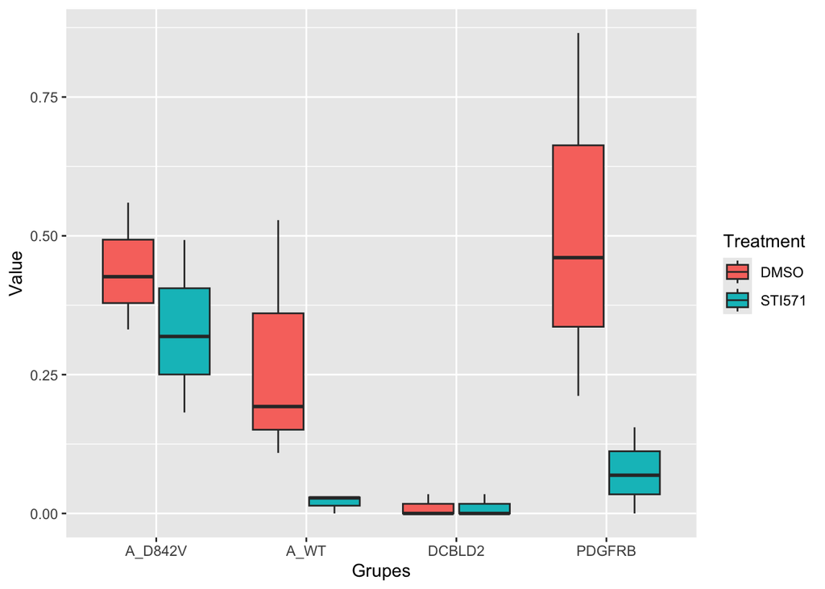

```r
#Lets create a simple box plot,
p1<-ggplot(abl, aes(x = Grupes, y = Value, fill = Treatment)) +
  geom_boxplot()

print(p1)
```

This is not very pretty. I do not like the color, my name groups are awful. Do not like the background and other stuff. So lets change it.

Lets do a couple of things first: 1. Rearrange the order of the groups to have consistency across figures and other results.

2. Change color, crating a variable name fill_colors, that way we could use the same across our paper.
3. change the theme a use it consistently across the paper.
4. Lastly add labels.

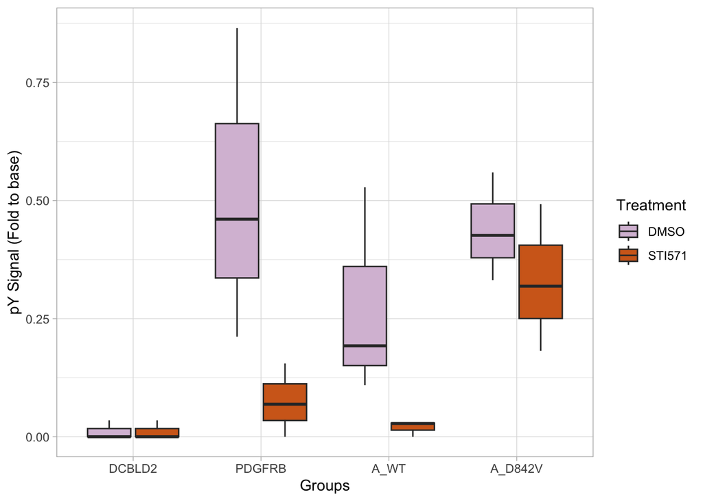

```r
 #Define the desired fill color
fill_colors <- c("DMSO" = "thistle", "STI571" = "chocolate")

p1 <- ggplot(abl, aes(x = factor(Grupes, levels = c("DCBLD2", "PDGFRB", "A_WT", "A_D842V")), y = Value, fill = Treatment)) + geom_boxplot() + #Notice the groups order is define.
  scale_fill_manual(values = fill_colors) + #Fill accordingly to groups
  labs( x = "Groups", #Labels
       y = "pY Signal (Fold to base)",
       fill = "Treatment") +
  theme_light()
# Display the plot
print(p1)
```

This is starting to look way better. But there is a couple of extra things to do.

1. Change the names to of goup variables. Notice we are using a short version to work in R, but this can be change.

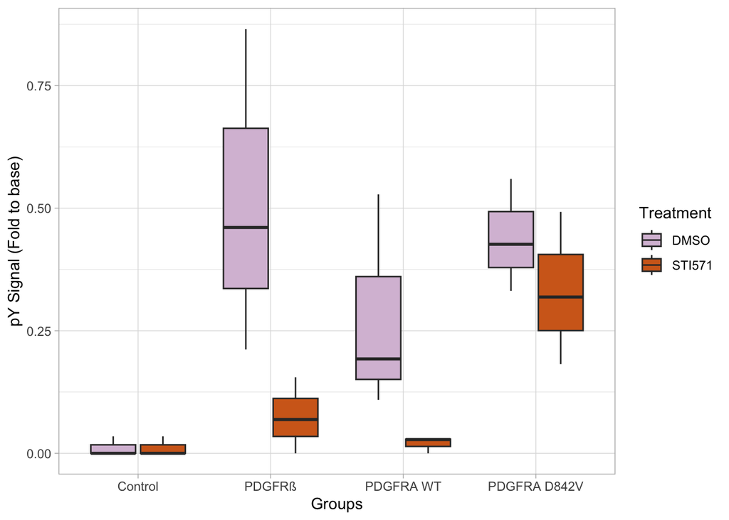

```r
# Change the group names
new_names <- c("Control", "PDGFRß", "PDGFRA WT", "PDGFRA D842V")

# Updated plot with new group names
p2 <- p1 + scale_x_discrete(labels = new_names)
print(p2)
```

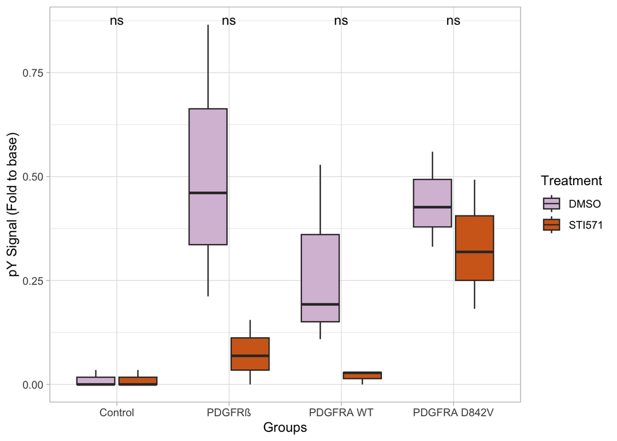

```r
p2 <- ggplot(abl, aes(x = factor(Grupes, levels = c("DCBLD2", "PDGFRB", "A_WT", "A_D842V")), y = Value, fill = Treatment)) +
  geom_boxplot() +
  scale_fill_manual(values = fill_colors) +
  labs(x = "Groups", y = "pY Signal (Fold to base)", fill = "Treatment") +
  theme_light() +
  stat_compare_means(aes(group = Treatment), method = "t.test", label = "p.signif")

p3 <- p2 + scale_x_discrete(labels = new_names)
print(p3)
```

Now lets extract the figure to a new pdf, jpg or tiff.

```r
#Save to PDF
ggsave("plot.pdf", p3, device = "pdf")
#Save o JPG
ggsave("plot.jpg", p3, device = "jpg")
#Lastly, save tiff 300 dpi as usually they ask.

ggsave("plot.tiff", p3, device = "tiff", dpi = 300)
```